# getting_started_with_R

Caroline Sanicola

July 24, 2025

# —– Getting Started with R: An Introduction for Biologists —–

Sources: 1. Getting Started with R

*Keyboard shortcuts:* - `<-` (assignment operator) - Windows: `Alt + -` - Mac: `Option + -` - `%>%` (pipe operator) - Windows: `Ctrl + Shift + M` - Mac: `Cmd + Shift + M` - (Un)Comment Selection - Windows: `Ctrl + Shift + C` - Mac: `Cmd + Shift + C` - to insert a code block in `.Rmd`: - Windows: `Ctrl + Alt + I` - Mac: `Cmd + Option + I` ___

## —– Import, Explore, Graph —–

### —– Getting Started —–

- where the data is located is the `PATH` and usually is convention to use forward slashes
- the `R CONSOLE` is the window into the engine of R
  - this is where you send and it accepts commands
- the second window is the `SCRIPT`
- annotations(commenting) are done with `#`
- functions are what we are asking to do in R
  - to clear the “brain” of R, we run `ls.rm` which stands for `rm` = remove and `ls` = list
    - `rm(list=ls())`

```r
rm(list=ls())
# list=ls() is asking R to make a list of these objects
# rm() asks R to remove all of these objects from this list
# ls() gives a list of all objects in R's "brain"
```

- to see where R is looking at, you get ask to get what the current working directory is using `getwd()`
  - to set the working directory, you use `setwd()`
- the first thing you should do when running a script for the first time:

```r
# ------------------------------------------
# User Name
# January 1, 2000
# Analysis of Trends
# ------------------------------------------

# Reset R's brain
rm(list=ls())

# getwd tells you where R is currently looking
getwd()
```

```
[1] "D:/GitHub/important-reference-repo/R"
```

```r
# setwd tells R where to look
setwd("D:/GitHub/important-reference-repo/R")

# use getwd to confirm that R is now looking here
getwd()
```

```
[1] "D:/GitHub/important-reference-repo/R"
```

- to execute a script, you can use the windows/mac shortcuts:
  - Windows: `CTRL + R`
  - Mac: `cmd + Return`

### —– Importing and Exploring ——

- getting data into R: `read.csv()`

```r
comp.dat <- read.csv('D:/GitHub/important-reference-repo/R/data/compensation.csv')

ls() # this will show that the new dataset has been loaded in
```

- to see the data in this dataset, there are a few key functions to use:
  - `names()` - tells you the names you assigned each column
  - `head()` - returns the first 6 rows of the dataset
  - `dim()` - tells you the number of rows and columns (**dimension**) of the dataset
  - `str()` - returns the structure of the dataset

```r
summary(comp.dat)
```

```
      Root            Fruit          Grazing
 Min.   : 4.426   Min.   : 14.73   Length:40
 1st Qu.: 6.083   1st Qu.: 41.15   Class :character
 Median : 7.123   Median : 60.88   Mode  :character
 Mean   : 7.181   Mean   : 59.41
 3rd Qu.: 8.510   3rd Qu.: 76.19
 Max.   :10.253   Max.   :116.05
```

- using the `dim()` should make you check to see the data was imported correctly and that there are matching rows and columns to the `.csv` file
- `summary()` is a **function** that will return a summary of the **numeric data** in the dataset (median, mean, inter-quartile range, minimum, maximum) and a levels and sample sizes of the **categoric** values

```r
summary(comp.dat)
```

- sometimes, when you want to take **subsets** of the data to do something like performing a **regression** model, you select specific columns that are called **indexing** the data.
  - if all of the data in the subset is the same type, you can use a **matrix** which is a set of values that are all the same type
    - either indexing or creating a matrix, you use `[]` square brackets and `,` commas
      - the rule is *rows-then-columns-always*

```r
comp.dat$Grazing
```

```
 [1] "Ungrazed" "Ungrazed" "Ungrazed" "Ungrazed" "Ungrazed" "Ungrazed" "Ungrazed" "Ungrazed" "Ungrazed" "Ungrazed" "Ungrazed" "Ungrazed" "Ungrazed" "Ungrazed" "Ungrazed" "Ungrazed"
[17] "Ungrazed" "Ungrazed" "Ungrazed" "Ungrazed" "Grazed"   "Grazed"   "Grazed"   "Grazed"   "Grazed"   "Grazed"   "Grazed"   "Grazed"   "Grazed"   "Grazed"   "Grazed"   "Grazed"
[33] "Grazed"   "Grazed"   "Grazed"   "Grazed"   "Grazed"   "Grazed"   "Grazed"   "Grazed"
```

- you can also call a column by using the `$` symbol

```r
comp.dat$Grazing
```

- subsetting the data, you can use the `subset()` function
  - the syntax is: `subset(data.frame.name, column.name == value)`

```r
# if we want to look at the subset of data in the comp.dat df where we look only at the rows which have "Grazed" in the "Grazing" column
subset(comp.dat, Grazing == "Grazed")
```

### —– Graphs —–

- the first start of data analysis SHOULD NEVER start with a statistical analysis, ALWAYS start with a picture first
  - this is so that you have an expected pattern of what the data should look like
    - this is to compare to if once you start running things, it starts not looking like that
- two main figure types that are important are:
  - **bar graph +- error bars** - requires **mean** values of some variabel to generate the heights of the bars and then some variability to add **error bars**
    - **tapply** - produces a **matrix** of aggregate data
      - accommodates a range of functions (mean, standard deviation, etc)
      - is the “best friend” of **barplot** because tapploy is a function that produces a matrix and barplot loves matrix
  - **scatterplot**

```r
# Set the working directory to the folder with all the stuff in it.
# note ~ for home directory in Mac/Linux/Unix
# /'s show path to "getting_started_with_R" folder
setwd("D:/GitHub/important-reference-repo/R/data/")
```

[output not shown]

```r
# Read in the data using read.csv function and assign it to the
# object called mydata
mydata <- read.csv("D:/GitHub/important-reference-repo/R/data/compensation.csv")
# make sure the data are what I wanted
head(mydata)
```

|  | Root | Fruit | Grazing |
| --- | --- | --- | --- |
| 1 | 6.225 | 59.77 | Ungrazed |
| 2 | 6.487 | 60.98 | Ungrazed |
| 3 | 4.919 | 14.73 | Ungrazed |
| 4 | 5.130 | 19.28 | Ungrazed |
| 5 | 5.417 | 34.25 | Ungrazed |
| 6 | 5.359 | 35.53 | Ungrazed |

```r
str(mydata)
```

```
'data.frame':   40 obs. of  3 variables:
 $ Root   : num  6.22 6.49 4.92 5.13 5.42 ...
 $ Fruit  : num  59.8 61 14.7 19.3 34.2 ...
 $ Grazing: chr  "Ungrazed" "Ungrazed" "Ungrazed" "Ungrazed" ...
```

- no we want to think from this data what we might want to plot:
  - we might want to explore mean +- standard deviation of fruit production for grazed and un-grazed conditions
    - we can make a barplot with standard deviation error bars
      - can also include text inside each bar (sample size used to calculate the mean and standard deviation)
        - first we need to calculate the means, the stdev and the sample size
          - use tapply!

```r
# Calculate mean of each group using tapply, which returns a matrix
mean.fruit <- tapply(mydata$Fruit, list(mydata$Grazing), mean)
mean.fruit
```

```
  Grazed Ungrazed
 67.9405  50.8805
```

```r
# Calculate standard deviation of each group
# using tapply, which returns a matrix-it will be the same dimension as mean.fruit
sd.fruit <- tapply(mydata$Fruit, list(mydata$Grazing), sd)
sd.fruit
```

```
  Grazed Ungrazed
24.96081 21.75897
```

```r
# Calculate sample size in each group
n.fruit <- tapply(mydata$Fruit, list(mydata$Grazing), length)
n.fruit
```

```
  Grazed Ungrazed
      20       20
```

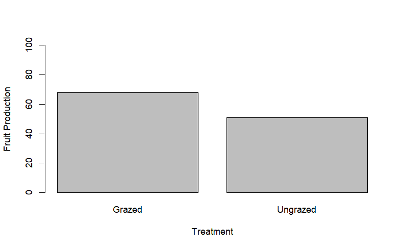

```r
barplot(mean.fruit,
        xlab = "Treatment",
        ylab = "Fruit Production",
        ylim = c(0,100)) # c is a function in R that is for combining values into a vector; since the ylim needs a min and max for the axis, we use a vector to do this
```

- using `?barplot` we can see how to add the text and error bars

```r
barplot(mean.fruit,
        xlab = "Treatment",
        ylab = "Fruit Production",
        ylim = c(0,100)) # c is a function in R that is for combining values into a vector; since the ylim needs a min and max for the axis, we use a vector to do this
```

- there is no automated way to do error bars in R
  - there are packages you can do this with (`gplots`, `Hmisc`, `plotrix`, `ggplot2`)
  - the native way to do this is to add a line with things on the ends (aka `arrows`)
    - the bottom of the line should be the middle of the bars -> so we need to get the mid points of the bars

```r
mids <- barplot(mean.fruit,
                xlab = "Treatment",
                ylab = "Fruit Production",
                ylim = c(0,100))
mids
```

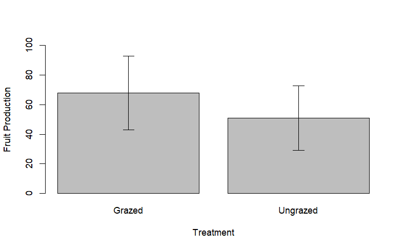

```r
# Make a barplot using the means returned from tapply
mids <- barplot(mean.fruit,
                xlab = "Treatment",
                ylab = "Fruit Production",
                ylim = c(0,100))
# Use the arrows to put error bars on the plot
arrows(mids, mean.fruit - sd.fruit, mids, mean.fruit + sd.fruit,
       code = 3, # tells arrows to draw "arrows" at both ends of the line
       angle = 90, # makes the arrow heads 90 degrees-flat
       length = 0.1) # makes them short (0.1 mm)
```

- now the last step is to add the text
  - the function to do this is `text()`

```r
# Make a barplot using the means returned from tapply
mids <- barplot(mean.fruit,
                xlab = "Treatment",
                ylab = "Fruit Production",
                ylim = c(0,100))
# Use the arrows to put error bars on the plot
arrows(mids, mean.fruit - sd.fruit, mids, mean.fruit + sd.fruit,
       code = 3, # tells arrows to draw "arrows" at both ends of the line
       angle = 90, # makes the arrow heads 90 degrees-flat
       length = 0.1) # makes them short (0.1 mm)
```

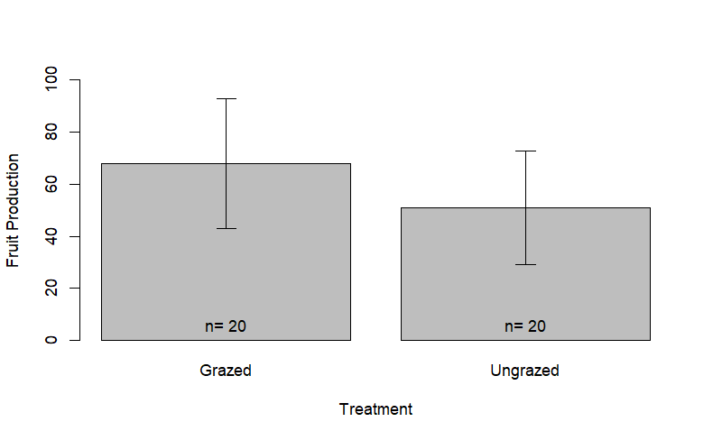

```r
# Add text at the midpoints (x) and at height 2 on the y-axis
# paste the words n=followed by the n.fruit values
text(mids, 6, paste("n=", n.fruit))
```

#### —– Test —–

- try to recreate the Figure 4.6 plot

```r
?barplot
```

```r
# load in the data
cow_growth <- read.csv("D:/GitHub/important-reference-repo/R/data/growth.csv")

# Calculate mean of each group using tapply, which returns a matrix
mean.comb <- tapply(cow_growth$gain, list(cow_growth$supplement, cow_growth$diet), mean)

# Calculate standard deviation of each group
sd.comb <- tapply(cow_growth$gain, list(cow_growth$supplement, cow_growth$diet), sd)

# Calculate sample size in each group
n.comb <- tapply(cow_growth$gain, list(cow_growth$supplement, cow_growth$diet), length)

# x is Feed; y is Weight Gain; legend is supplement
# make a barplot using the means returned from tapply
mids <- barplot(mean.comb,
                beside = TRUE,
                main = "Types of Feeds and Supplements by Weight Gain",
                xlab = "Feed",
                ylab = "Weight Gain",
                ylim = c(0,max(mean.comb + sd.comb, na.rm = TRUE) *1.2),
                legend.text = rownames(mean.comb),
                args.legend = list(x = "topright"))

# Use Arrows to put error bars on the plot
arrows(mids, mean.comb - sd.comb, mids, mean.comb + sd.comb,
       code = 3, angle = 90, length = 0.1)
```

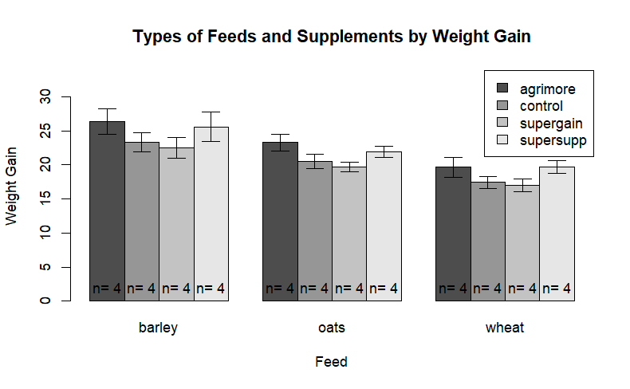

```r
# Add text at the midpoints(x) and at height 6 on the y-axis
# paste the words n=followed by the n.gain values
text(mids, 2, paste("n=", n.comb))
```

#### —– Scatterplots —–

- the function for plotting scatterplots is just `plot`
  - it can plot x-y scattergplots given two columns of data
    - `plot(data.set$x.column, data.set$y.column)`
      - a variation is `plot.formula` which requires: **formula** and a **data frame**
        - `plot(y ~ x, data = dataset)`

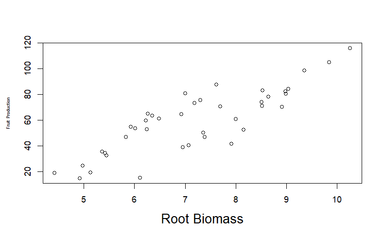

```r
plot(Fruit ~ Root, data = mydata,
     xlab = list("Root Biomass", cex = 1.5), # increases the default size by 1.5 times
     ylab = list("Fruit Production", cex = 0.5)) # decreases the size by 0.5 times (half)
```

```r
# this executes the same things as above
plot(Fruit ~ Root, data = mydata)
```

```r
?par
```

- other **plot** arguments:
  - `pch` - point character (controls the shape (symbol) of the points)
  - `col` - the color
  - `bg` - the point background color

```r
?par
```

- **par** is short for graphical parameters
  - this will list all the things in your plot you can change
    - we can use `?points` to see what customizable points are available

```r
?points
```

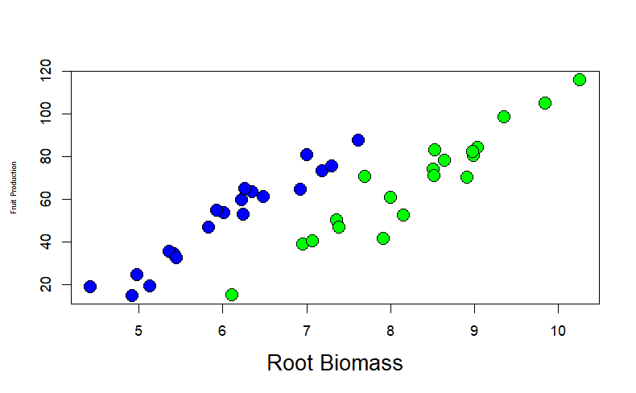

```r
culr <- ifelse(mydata$Grazing == "Grazed", "green", "blue")
plot(Fruit ~ Root, data = mydata,
     xlab = list("Root Biomass", cex = 1.5),
     ylab = list("Fruit Production", cex = 0.5),
     cex = 2, pch = 21, bg = culr)
```

- if we want to add color, we can create a function to specify which colors we want to apply to which values of the data

```r
culr <- ifelse(mydata$Grazing == "Grazed", "green", "blue")
plot(Fruit ~ Root, data = mydata,
     xlab = list("Root Biomass", cex = 1.5),
     ylab = list("Fruit Production", cex = 0.5),
     cex = 2, pch = 21, bg = culr)
```

- now we can add a **legend** and see what options we have available

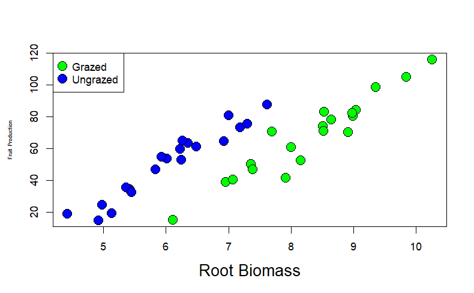

```r
culr <- ifelse(mydata$Grazing == "Grazed", "green", "blue")
plot(Fruit ~ Root, data = mydata,
     xlab = list("Root Biomass", cex = 1.5),
     ylab = list("Fruit Production", cex = 0.5),
     cex = 2, pch = 21, bg = culr)
legend("topleft", legend = c("Grazed", "Ungrazed"), # this is going to stick the legend in the top left corner of the plot
       pch = 21, pt.bg = c("green", "blue"), pt.cex = 2)
```

- there are two versions of the legend we can try

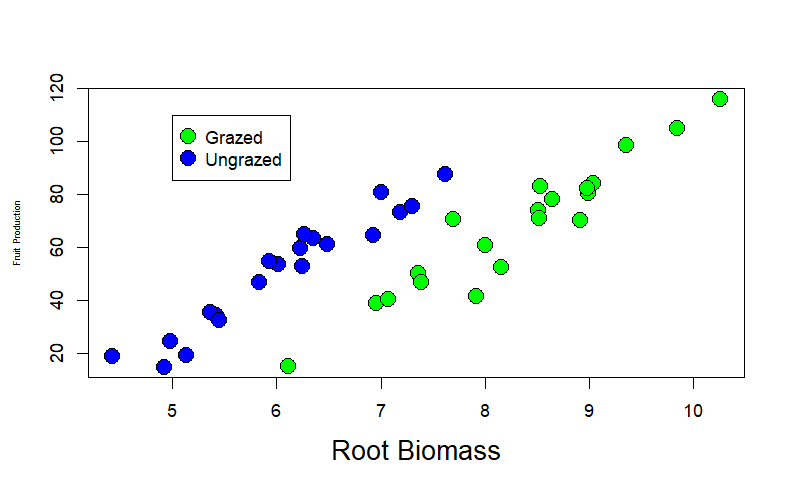

```r
culr <- ifelse(mydata$Grazing == "Grazed", "green", "blue")
plot(Fruit ~ Root, data = mydata,
     xlab = list("Root Biomass", cex = 1.5),
     ylab = list("Fruit Production", cex = 0.5),
     cex = 2, pch = 21, bg = culr)
legend(5, 110, legend = c("Grazed", "Ungrazed"), # this is going to put the legend at plot point (5,110) on the graph
       pch = 21, pt.bg = c("green", "blue"), pt.cex = 2)
```

```r
culr <- ifelse(mydata$Grazing == "Grazed", "green", "blue")
plot(Fruit ~ Root, data = mydata,
     xlab = list("Root Biomass", cex = 1.5),
     ylab = list("Fruit Production", cex = 0.5),
     cex = 2, pch = 21, bg = culr)
legend(5, 110, legend = c("Grazed", "Ungrazed"), # this is going to put the legend at plot point (5,110) on the graph
       pch = 21, pt.bg = c("green", "blue"), pt.cex = 2)
```

#### —– Using the layout() and pdf() function to save multiple plots —–

```r
# This snippet of code writes a pdf of a multi-panel plot to your hard drive.
# It firsts creates some fake data.
# It then opens a pdf "device" on your computer which prepares your
# working directory to receive a pdf.
# It then executes some plotting code and writes the pdf to the working
# directory with a specific filename you have specified.
# Finally, the dev.off  () function closes the connection to the
# working directory, turning off   the pdf device; this final step
# ensures that subsequent plotting is written to the graphics window
# Make the data
time <- seq(0,9.9,0.1) # a sequence
weight <- (time^2) + rnorm(100,0,10) # time^2 with deviation
temperature <- factor(sample(c("cold","hot"), 100, replace = TRUE))
# Identify your working directory - this is where the PDF will be found
getwd()
```

```
[1] "D:/GitHub/important-reference-repo/R"
```

```r
# OPEN THE PDF DEVICE—specify a file name and a paper size
pdf(file = "PracticePDF.pdf", paper = "a4")
# set the layout of the plotting
# here we specify a 2 x 2 plot and place the figures into the plot by row
layout(matrix(c(1, 2, 3, 4), 2, 2, byrow = TRUE))
# do your plotting—here we add three figures to the layout
# we also use the function mtext() to add letters outside each of the
# boxes as identifiers for a figure legend in your manuscript
plot(weight ~ time, pch = 21, bg = "green")
mtext("A", side = 3, line = 2, adj = 0)

plot(weight ~ temperature)
```

```r
mtext("B", side = 3, line= 2, adj = 0)

plot(weight ~ time, col = c("black","red")[temperature])
mtext("C", side = 3, line = 2, adj = 0)

# Close the connection to your hard drive
dev.off() # this NEEDS to be there or else you wont be able to actually access the pdf
```

```r
# Now, go to your hard drive and look in the working directory for the pdf.
```

#### —– A very brief introduction to lattice plots, from the lattice library, using xyplot() —–

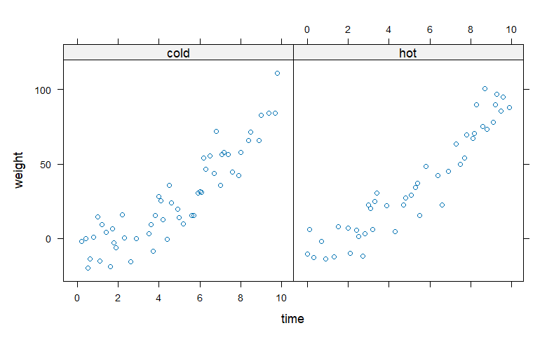

```r
# This snippet of code shows the basics of the lattice
# library using the function xyplot()
# First, we load the package lattice as a library

library(lattice) # Comes with the base installation of R

# Now we make up some data
time <- seq(0, 9.9, 0.1) # a sequence
weight <- (time^2) + rnorm(100, 0, 10) # time^2 with deviation

# random assignment of temperature
temperature <- factor(sample(c("cold", "hot"), 100,
                             replace = TRUE))

# Now, we use xyplot in two different ways
# First, we use the panel plot functionality via the "|" symbol
# (also known as a pipe)
# this creates two panels of weight versus time, each panel
# representing the two temperatures
xyplot(weight ~ time|temperature)
```

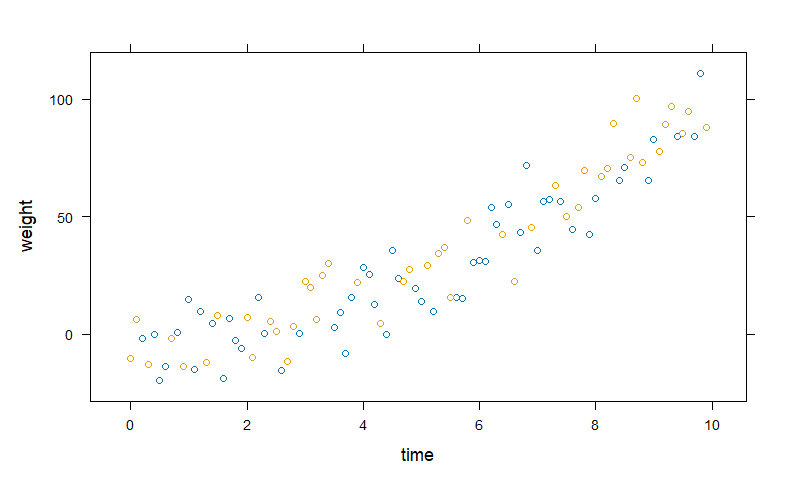

```r
# Next we use the groups argument to color each symbol according
# to the two different temperatures:
xyplot(weight ~ time, groups = temperature)
```

## —– Doing your statistics —–

### —– Chi-square —–

- the chi-square contingency table analysis is an analysis of **count data**
  - a test of association among two or more variables
- currently testing the null hypothesis that there is no association between ladybird colors and their habitat
  - the alternative hypothesis is that there is an association

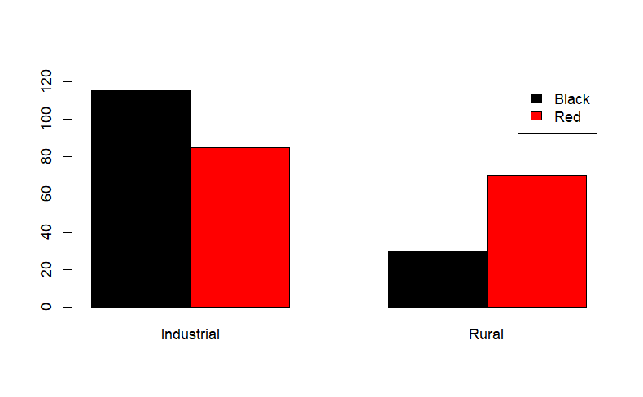

```r
# we are going to create a matrix of the
chi.data <- matrix(c(115, 30, 85, 70), 2, 2, byrow = TRUE,
                   dimnames = list(c("Black", "Red"), c("Industrial", "Rural")))

barplot(chi.data, beside = TRUE, col = c("Black", "Red"),
        ylim = c(0,125), legend = TRUE)
```

```r
chisq.test(chi.data)
```

```
    Pearson's Chi-squared test with Yates' continuity correction

data:  chi.data
X-squared = 19.103, df = 1, p-value = 1.239e-05
```

- now we can test the associations with a chi-square test

```r
chisq.test(chi.data)
```

- the output shows that there is a very small probability (p=0.00001239) that the patterns are by chance
  - this allows us to reject the null hypothesis and say that there is an association with habitat and color
  - we would write this up in a paper by stating: “We tested the hypothesis that there is an association between color morphs of ladybirds and industrial and rural habits. Ladybird color morphs are not uniformly distributed in the habitats (X^2 = 19.1, df=1, p<0.001), with black morphs being more frequent in industrial habitats and red morphs are frequent in rural habitats.”
- by assigning the chi-square results to a name, you will have access to the:
  - “statistic”, “parameter”, “p.value”, “method”, “data.name”, “observed”, “expected”, “residuals”

```r
my.chi <- chisq.test(chi.data)
names(my.chi)

my.chi$expected
```

### —– Two sample t-test —–

- the two sample t-test is a comparison of the means of two groups
  - its appropriate when sample sizes in each group are small
    - there are assumptions about the data being analyzed:
      - data in each group are normally distributed
      - their variance are similar
- now we want to look at ozone levels in two gardens
  - ozone concentrations in part per hundred million (pphm) on ten summer days
    - over 8 pphm can damage certain crops

```r
ozone <- read.csv("D:/GitHub/important-reference-repo/R/data/gardens.csv")
names(ozone)
head(ozone)
str(ozone)
```

```r
# Read in the data
ozone <- read.csv("D:/GitHub/important-reference-repo/R/data/gardens.csv")
# Check the data
head(ozone)
```

|  | Ozone | Garden |
| --- | --- | --- |
| 1 | 3 | A |
| 2 | 4 | A |
| 3 | 4 | A |
| 4 | 3 | A |
| 5 | 2 | A |
| 6 | 3 | A |

```r
str(ozone)
```

```
'data.frame':   20 obs. of  2 variables:
 $ Ozone : int  3 4 4 3 2 3 1 3 5 2 ...
 $ Garden: chr  "A" "A" "A" "A" ...
```

[figure not shown]

```r
# subset the data
GA <- ozone[ozone$Garden == "A", ]
GB <- subset(ozone, Garden == "B")

# make a single figure with two plots (2 rows, 1 column plotting grid)
par(mfrow = c(2, 1))
hist(GA$Ozone)
hist(GB$Ozone)
```

- the above looks the same but the x-axis are different for each

```r
# do a t.test now
t.test(GA$Ozone, GB$Ozone)
```

```
    Welch Two Sample t-test

data:  GA$Ozone and GB$Ozone
t = -3.873, df = 18, p-value = 0.001115
alternative hypothesis: true difference in means is not equal to 0
95 percent confidence interval:
 -3.0849115 -0.9150885
sample estimates:
mean of x mean of y
        3         5
```

- now we can see there is a skew in the data between different zones
- now we can do the `t.test()`

```r
# do a t.test now
t.test(GA$Ozone, GB$Ozone)
```

- there results are showing that since the difference would be 0 if the means were the same and since they are not, there is significance

### —– General linear models —–

- these include regression, ANOVA, and ANCOVA

```r
limp <- read.csv("D:/GitHub/important-reference-repo/R/data/limpet.csv")

limp$SEASON <- factor(limp$SEASON, levels = c("spring", "summer")) # without doing this, the column returns NA values when color assignments
names(limp)
head(limp)
str(limp)
```

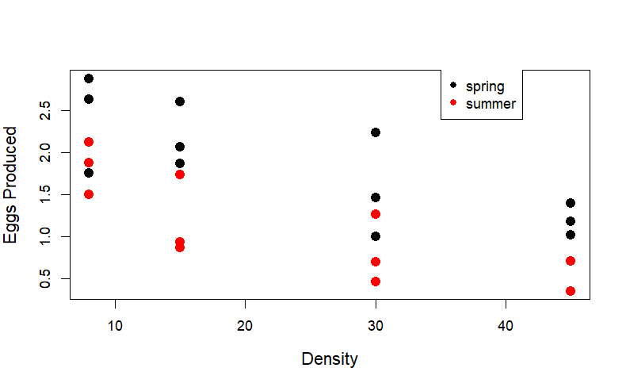

```r
# plot window
par(mfrow = c(1,1))

# the plot
plot(EGGS ~ DENSITY, data = limp, pch = 19, cex = 1.5,
     col = c("black", "red")[limp$SEASON],
     xlab = list("Density", cex = 1.2),
     ylab = list("Eggs Produced", cex = 1.2))

# add a legend
legend(35, 3, legend = c("spring", "summer"),
       col = c("black", "red"), pch = c(19, 19))
```

- from the above graph, we can clearly see a decline in production with an increase in density
- also from this, we are now asking: do we get a better description of the data by using more than one intercept and more than one slope?

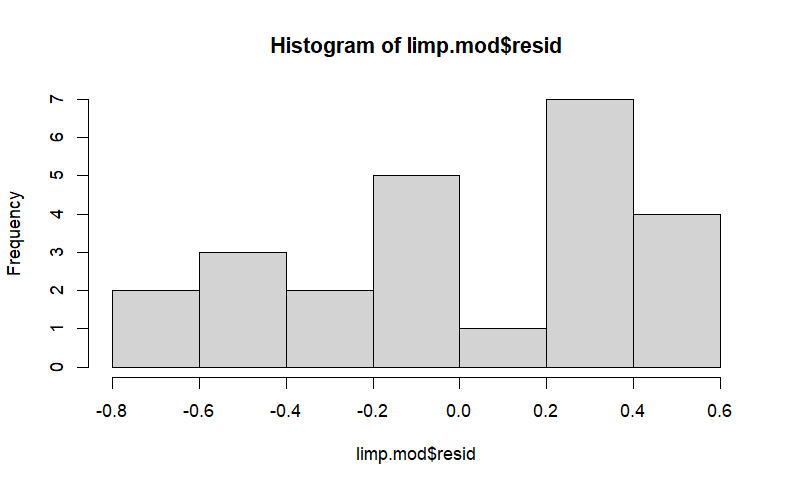

```r
hist(limp.mod$resid)
```

```r
par(mfrow = c(2,2)) # make a four panel plot window
plot(limp.mod) # add the four diagnostic plots to the window
```

[output not shown]

```r
hist(limp.mod$resid)
```

- now there are two functions that can aid in our interpretation of a general linear model:
  - `anova()` - produces an ANOVA table listing sums of squares, mean squares, F-values, and P-values (IT DOESN’T ACTUALLY PERFORM AN ANOVA)
  - `summary()` - (when given an **lm**) returns a table of coefficients (slopes and intercepts), standard errors, and t-values

```r
anova(limp.mod)
```

```r
names(limp.mod)
```

```
 [1] "coefficients"  "residuals"     "effects"       "rank"          "fitted.values" "assign"
 [7] "qr"            "df.residual"   "contrasts"     "xlevels"       "call"          "terms"
[13] "model"
```

```r
names(limp.mod)
```

```r
coef(limp.mod)
```

```r
# plot window
par(mfrow = c(1,1))

# the plot
plot(EGGS ~ DENSITY, data = limp, pch = 19, cex = 1.5,
     col = c("black", "red")[limp$SEASON],
     xlab = list("Density", cex = 1.2),
     ylab = list("Eggs Produced", cex = 1.2))

# add a legend
legend(35, 3, legend = c("spring", "summer"),
       col = c("black", "red"), pch = c(19, 19))
```

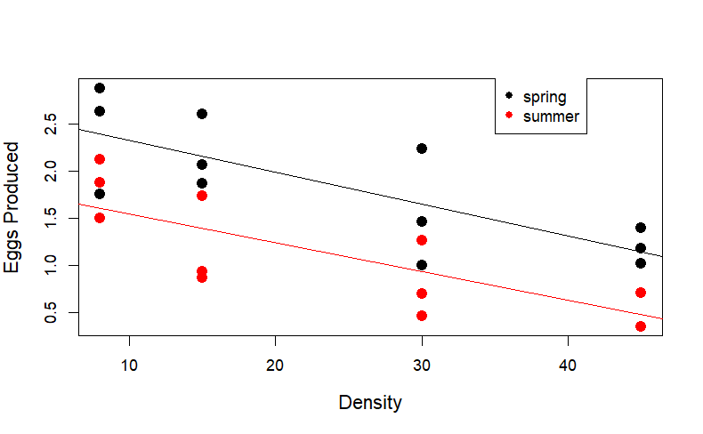

```r
abline(coef(limp.mod)[1], coef(limp.mod)[2])

abline(coef(limp.mod)[1] + coef(limp.mod)[3], # summer intercept
       coef(limp.mod)[2] + coef(limp.mod)[4], # summer slope
       col="red")
```